# Assignment2

#### 1.4.3 Refit *medv* with Natural Spline.

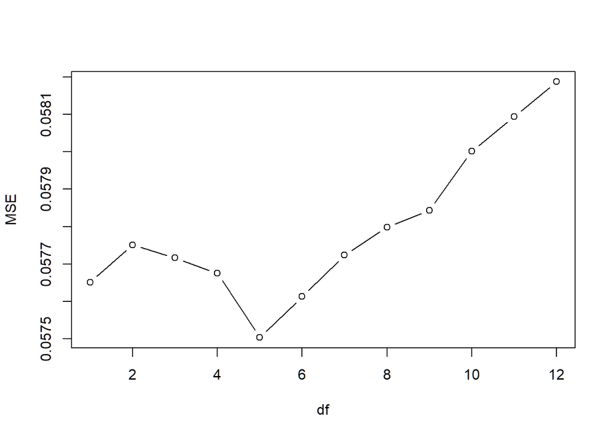

```r
MSE <- rep(0,12)
for (i in 1:12){
  Data <- RegressionData
  Data$medvns <- ns(RegressionData$medv, df = i)
  fit <- train(nox ~ poly(age,3) + ns(dis,4) + bs(lstat,8) + medvns,
               data = Data,
               method = 'lm',
               trControl=train_control)
  MSE[i] <- fit$results$RMSE
}

plot(1:12, MSE, type='b', xlab = 'df')
```

```r
which.min(MSE)
```

```
## [1] 5
```

```r
MSE[which.min(MSE)]
```

```
## [1] 0.05750367
```

Natural spline with df = 5 has smallest MSE = 0.0575.

Compare between ns(df = 5), bs(df = 4) and 4th polynomia.

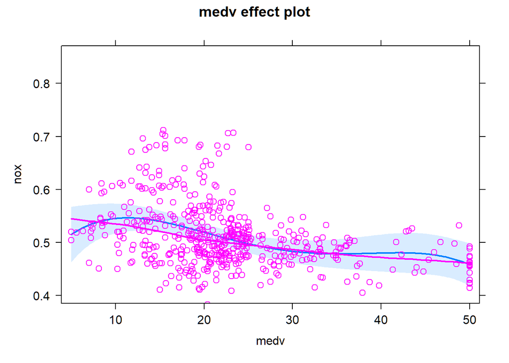

```r
lm.fit.medv4 <- lm(nox ~ poly(age,3) + ns(dis,4) + bs(lstat,8)
                   + poly(medv,4),
                      data = RegressionData)
lm.bs.medv4 <- lm(nox ~ poly(age,3) + ns(dis,4) + bs(lstat,8)
                   + bs(medv,4),
                      data = RegressionData)
lm.ns.medv5 <- lm(nox ~ poly(age,3) + ns(dis,4) + bs(lstat,8)
                   + ns(medv,5),
                      data = RegressionData)

plot(effect("medv", mod = lm.fit.medv4, partial.residuals = TRUE))
```

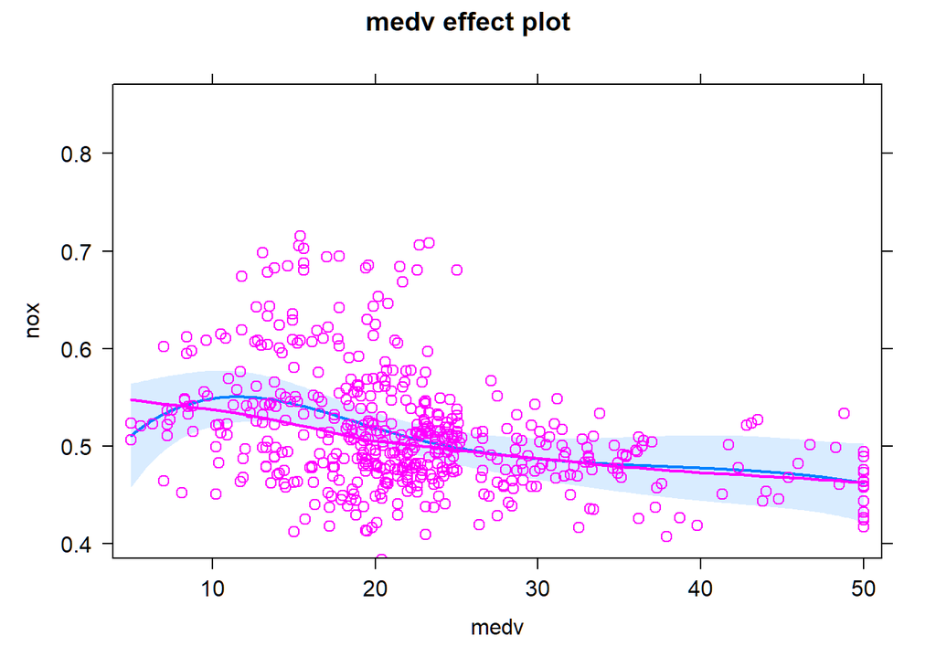

```r
plot(effect("medv", mod = lm.bs.medv4, partial.residuals = TRUE))
```

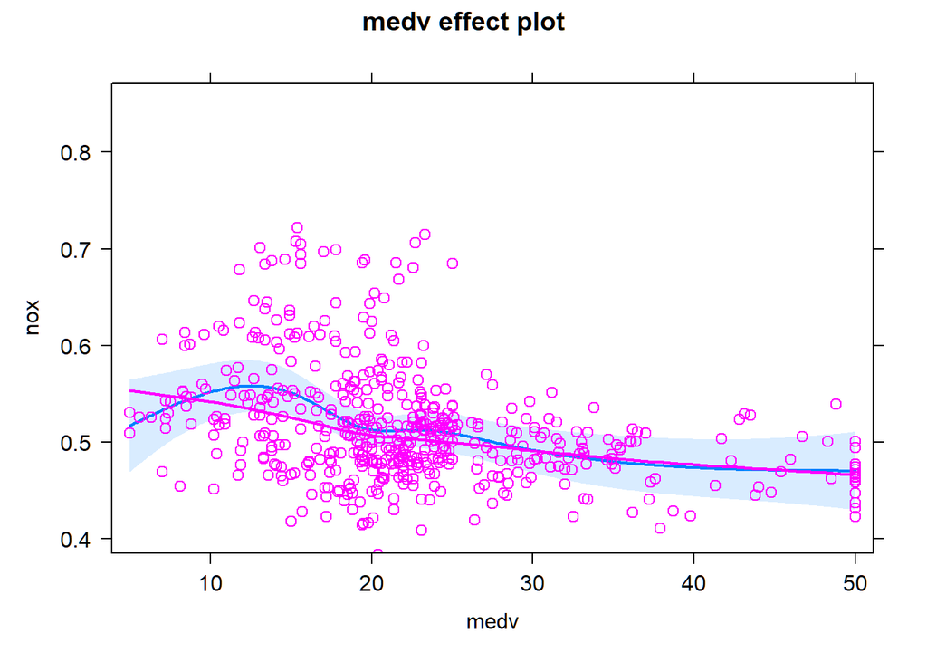

```r
plot(effect("medv", mod = lm.ns.medv5, partial.residuals = TRUE))
```

We choose natural spline with 5 df for *medv* which has smallest MSE among all fitting methods.

### Whole Model Build and Assumption Check 2

Thus, the whole model has been build. Now, we are supposed to check the assumption for this final model.

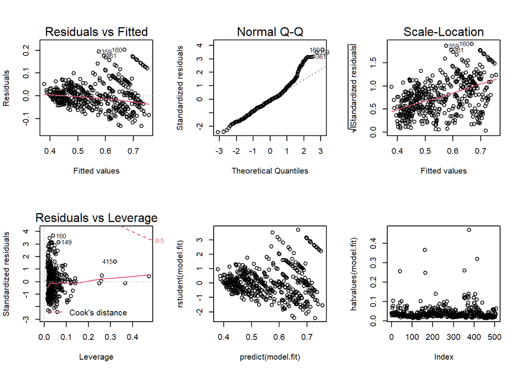

```r
model.fit <- lm.ns.medv5 <- lm(nox ~ poly(age,3) + ns(dis,4) + bs(lstat,8)
                   + ns(medv,5),
                      data = RegressionData)

par(mfrow = c(2, 3))
plot(model.fit)
plot(predict(model.fit), rstudent(model.fit))
plot(hatvalues(model.fit))
```

## Test model with different number of input variables

### Best Subsets

```r
## 0 inputs
mod.0 <- lm(nox ~ 1, data = RegressionData)

## 1 inputs
mod.1.1 <- lm(nox ~ poly(age,3), data = RegressionData)
mod.1.2 <- lm(nox ~ ns(dis,4), data = RegressionData)
mod.1.3 <- lm(nox ~ bs(lstat,8), data = RegressionData)
mod.1.4 <- lm(nox ~ ns(medv,5), data = RegressionData)
which.min(c(deviance(mod.1.1), deviance(mod.1.2),
            deviance(mod.1.3),deviance(mod.1.4)))
```

```
## [1] 2
```

```r
# mod.1.2 is the winner

## 2 inputs
mod.2.1 <- lm(nox ~ poly(age,3) + ns(dis,4), data = RegressionData)
mod.2.2 <- lm(nox ~ poly(age,3) + bs(lstat,8), data = RegressionData)
mod.2.3 <- lm(nox ~ poly(age,3) + ns(medv,5), data = RegressionData)
mod.2.4 <- lm(nox ~ ns(dis,4) + bs(lstat,8), data = RegressionData)
mod.2.5 <- lm(nox ~ ns(dis,4) + ns(medv,5), data = RegressionData)
mod.2.6 <- lm(nox ~ ns(medv,5) + bs(lstat,8), data = RegressionData)
which.min(c(deviance(mod.2.1), deviance(mod.2.2),
            deviance(mod.2.3),deviance(mod.2.4),
            deviance(mod.2.5),deviance(mod.2.6)))
```

```
## [1] 5
```

```r
# mod.2.5 is the winner

## 3 inputs
mod.3.1 <- gam(nox ~ poly(age,3) + ns(dis,4) + bs(lstat,8),
              data = RegressionData)
mod.3.2 <- lm(nox ~ poly(age,3) + ns(dis,4) + ns(medv,5),
              data = RegressionData)
mod.3.3 <- lm(nox ~ poly(age,3) + bs(lstat,8) + ns(medv,5),
              data = RegressionData)
mod.3.4 <- lm(nox ~ ns(dis,4) + bs(lstat,8) + ns(medv,5),
              data = RegressionData)
which.min(c(deviance(mod.3.1), deviance(mod.3.2),
            deviance(mod.3.3),deviance(mod.3.4)))
```

```
## [1] 4
```

```r
# mod.3.4 is the winner

## 4 inputs
mod.4 <- lm(nox ~ poly(age,3) + ns(dis,4) + bs(lstat,8)
                       + ns(medv,5),
              data = RegressionData)
```

### Cross-validation

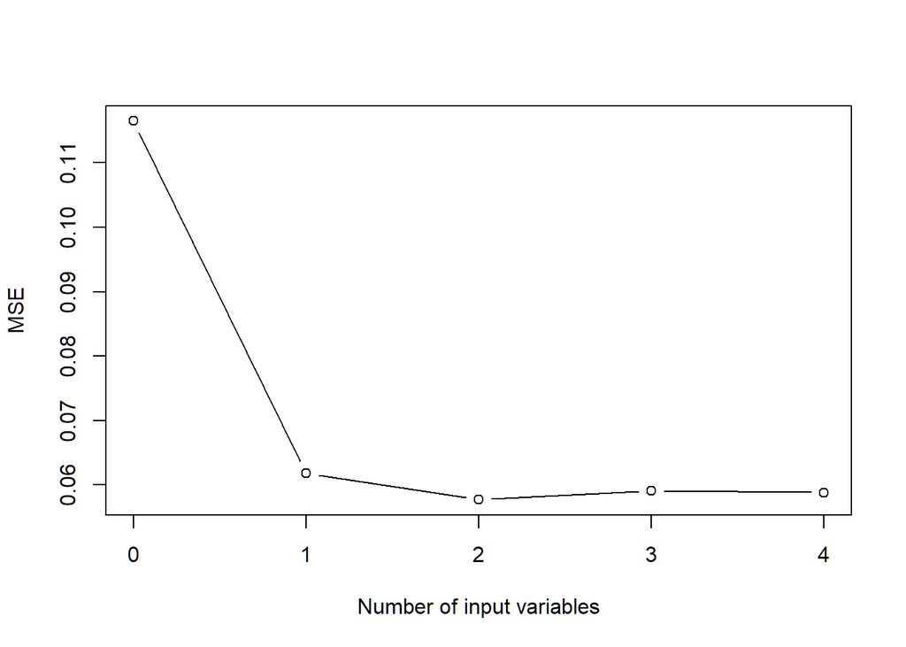

```r
RegressionData$const <- rep(0,dim(RegressionData)[1])
fit.0 <- train(nox ~ const,
               data = RegressionData, method = "lm",
               trCrontol = train_control)
fit.1 <- train(nox ~ ns(dis,4),
               data = RegressionData, method = "lm",
               trCrontol = train_control)
fit.2 <- train(nox ~ ns(dis,4) + ns(medv,5),
               data = RegressionData, method = "lm",
               trCrontol = train_control)
fit.3 <- train(nox ~ ns(dis,4) + bs(lstat,8) + ns(medv,5),
               data = RegressionData, method = "lm",
               trCrontol = train_control)
fit.4 <- train(nox ~ poly(age,3) + ns(dis,4) + bs(lstat,8)
                       + ns(medv,5),
              data = RegressionData, method = "lm",
               trCrontol = train_control)

mod.comp <- data.frame(MSE = c(fit.0$results$RMSE, fit.1$results$RMSE, fit.2$results$RMSE, fit.3$results$RMSE, fit.4$results$RMSE),
                       Inputs = c(0,1,2,3,4))
plot(mod.comp$Inputs, mod.comp$MSE, type = "b", xlab = "Number of input variables", ylab = "MSE")
```

```r
dfn_best <- mod.comp$Inputs[which.min(mod.comp$MSE)]

mod.comp$MSE[3]
```

```
## [1] 0.05771516
```

```r
mod.comp$MSE[5]
```

```
## [1] 0.05883094
```

```r
# Also, we can use ANOVA to compare the model performance
anova(mod.1.2, mod.2.5, mod.3.4, mod.4)
```

```
## Analysis of Variance Table
##
## Model 1: nox ~ ns(dis, 4)
## Model 2: nox ~ ns(dis, 4) + ns(medv, 5)
## Model 3: nox ~ ns(dis, 4) + bs(lstat, 8) + ns(medv, 5)
## Model 4: nox ~ poly(age, 3) + ns(dis, 4) + bs(lstat, 8) + ns(medv, 5)
##   Res.Df    RSS Df Sum of Sq       F    Pr(>F)
## 1    501 1.8858
## 2    496 1.6329  5  0.252865 15.8171 1.925e-14 ***
## 3    488 1.5780  8  0.054916  2.1469   0.03029 *
## 4    485 1.5507  3  0.027307  2.8469   0.03715 *
## ---
## Signif. codes:  0 '***' 0.001 '**' 0.01 '*' 0.05 '.' 0.1 ' ' 1
```

Now, let’s calculate the parameter for this model.

```r
summary(mod.2.5)
```

```
##
## Call:
## lm(formula = nox ~ ns(dis, 4) + ns(medv, 5), data = RegressionData)
##
## Residuals:
##       Min        1Q    Median        3Q       Max
## -0.131035 -0.034707 -0.004922  0.027763  0.213256
##
## Coefficients:
##               Estimate Std. Error t value Pr(>|t|)
## (Intercept)   0.698846   0.020492  34.104  < 2e-16 ***
## ns(dis, 4)1  -0.208664   0.015378 -13.569  < 2e-16 ***
## ns(dis, 4)2  -0.248323   0.016899 -14.695  < 2e-16 ***
## ns(dis, 4)3  -0.347434   0.032891 -10.563  < 2e-16 ***
## ns(dis, 4)4  -0.272266   0.029825  -9.129  < 2e-16 ***
## ns(medv, 5)1  0.011512   0.019666   0.585 0.558546
## ns(medv, 5)2  0.002627   0.022267   0.118 0.906144
## ns(medv, 5)3 -0.063655   0.018634  -3.416 0.000688 ***
## ns(medv, 5)4  0.035936   0.043541   0.825 0.409580
## ns(medv, 5)5 -0.069431   0.014723  -4.716 3.13e-06 ***
## ---
## Signif. codes:  0 '***' 0.001 '**' 0.01 '*' 0.05 '.' 0.1 ' ' 1
##
## Residual standard error: 0.05738 on 496 degrees of freedom
## Multiple R-squared:  0.7592, Adjusted R-squared:  0.7548
## F-statistic: 173.7 on 9 and 496 DF,  p-value: < 2.2e-16
```

So our final predicted model for nitrogen oxides concentration includes weighted mean of distances to five Boston employment centers and median value of owner-occupied homes, these two variables can explain 75.48% variance of nitrogen oxides concentration in Boston.

# Classification Problem

Because the classification problem is not quite dissimilar to regression mode, here we omit most of the narrative and just stress the different parts.

## Read in and Tidy Data

```r
ClassificationData <- Carseats[Carseats$ShelveLoc=="Good"|Carseats$ShelveLoc=="Bad",]
ClassificationData <- ClassificationData[,c(1,2,6,7,8)]

ClassificationData$ShelveLoc <- droplevels(ClassificationData$ShelveLoc)

ClassificationData$ShelveLoc<- factor(ClassificationData$ShelveLoc, levels = c("Bad", "Good"), labels = c('0', '1'))

str(ClassificationData)
```

```
## 'data.frame':    181 obs. of  5 variables:
##  $ Sales    : num  9.5 11.22 4.15 10.81 11.85 ...
##  $ CompPrice: num  138 111 141 124 136 121 117 115 107 118 ...
##  $ Price    : num  120 83 128 72 120 100 94 86 118 110 ...
##  $ ShelveLoc: Factor w/ 2 levels "0","1": 1 2 1 1 2 1 2 2 2 2 ...
##  $ Age      : num  42 65 38 78 67 26 50 53 52 63 ...
```

## Assumption test 1

### Linearity assumption

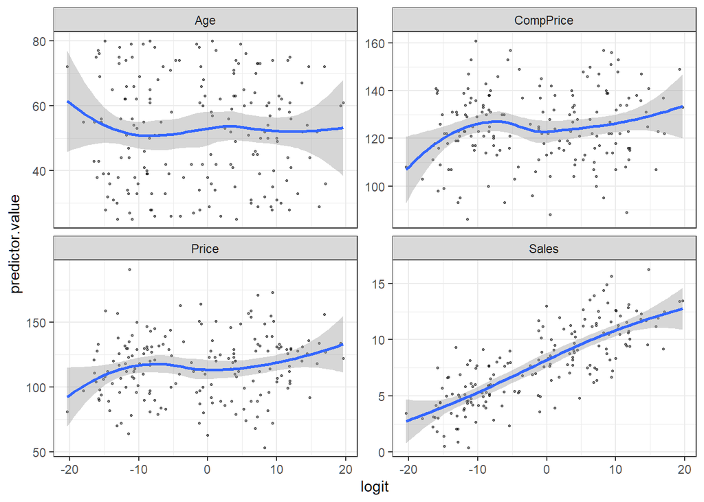

```r
model <- glm(ShelveLoc ~., data = ClassificationData,
               family = binomial)
# Select only numeric predictors

probabilities <- predict(model, type = "response")
predicted.classes <- ifelse(probabilities > 0.5, "Bad", "Good")

# Bind the logit and tidying the data for plot
mydata <- ClassificationData %>%
  dplyr::select_if(is.numeric)
predictors <- colnames(mydata)
mydata <- mydata %>%
  mutate(logit = log(probabilities/(1-probabilities))) %>%
  gather(key = "predictors", value = "predictor.value", -logit)

# Create the scatter plots:
ggplot(mydata, aes(logit, predictor.value))+
  geom_point(size = 0.5, alpha = 0.5) +
  geom_smooth(method = "loess") +
  theme_bw() +
  facet_wrap(~predictors, scales = "free_y")
```

The smoothed scatter plots show that these variables are all quite linearly associated with *ShelveLoc* in logit scale, especially for the *Sales*. But the relationship between Age/ComPrice doesn’t seem like linear or related. However, the *Price* variables are not 100% perfect, so I think it’s fine to try to fit with other methods for those three variables.

### Multicollinearity test

Now, let’s check the Multicollinearity problems.

```r
model <- glm(ShelveLoc ~., data = ClassificationData,
               family = binomial)
car::vif(model)
```

```
##     Sales CompPrice     Price       Age
## 26.637956  6.243205 30.044999  3.804585
```

The vif of *Sales* and *Price* as well as *ComPrice* >5. We should drop *Price*, which one has highest VIF. Thus, if later we want choose a linear model, we should at least drop several variables. Here, I decided to drop Age and CompPrice because these two variables seems like not associated with outcome.

```r
model <- glm(ShelveLoc ~.-CompPrice-Age, data = ClassificationData,
               family = binomial)
car::vif(model)
```

```
##   Sales   Price
## 3.15735 3.15735
```

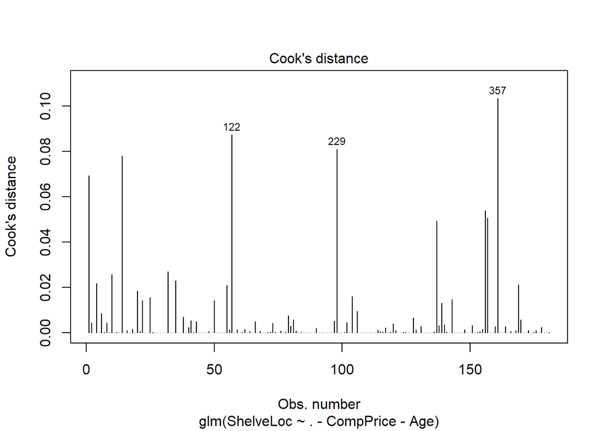

```r
# Examine treme data by the Cook’s distance values.
plot(model, which = 4, id.n = 3)
```

```r
# Extract model results
model.data <- augment(model) %>%
  mutate(index = 1:n())

model.data %>% top_n(3, .cooksd)
```

```
## # A tibble: 3 x 13
##   .rownames ShelveLoc Sales CompPrice Price   Age .fitted .resid .std.resid
##   <chr>     <fct>     <dbl>     <dbl> <dbl> <dbl>   <dbl>  <dbl>      <dbl>
## 1 122       0         11.7        125    87    28   2.30   -2.19      -2.22
## 2 229       0          5.4        149   163    26   0.983  -1.61      -1.68
## 3 357       1          3.58       142   164    72  -1.49    1.84       1.90
## # ... with 4 more variables: .hat <dbl>, .sigma <dbl>, .cooksd <dbl>,
## #   index <int>
```

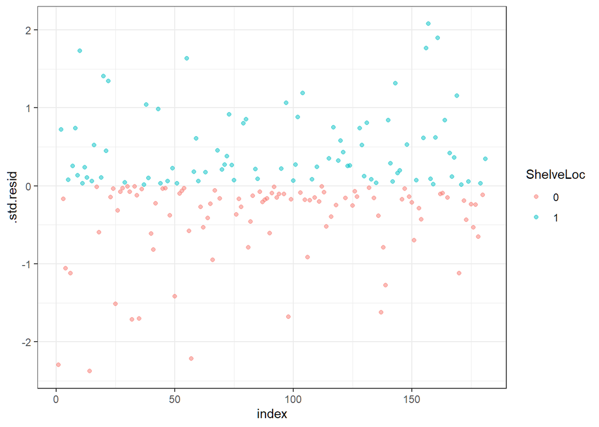

```r
# Plot the standardized residuals:
ggplot(model.data, aes(index, .std.resid)) +
  geom_point(aes(color = ShelveLoc), alpha = .5) +
  theme_bw()
```

```r
# Filter potential influential data points with abs(.std.res) > 3:
model.data %>%
  filter(abs(.std.resid) > 3)
```

```
## # A tibble: 0 x 13
## # ... with 13 variables: .rownames <chr>, ShelveLoc <fct>, Sales <dbl>,
## #   CompPrice <dbl>, Price <dbl>, Age <dbl>, .fitted <dbl>, .resid <dbl>,
## #   .std.resid <dbl>, .hat <dbl>, .sigma <dbl>, .cooksd <dbl>, index <int>
```

As results above, there is some outliers, but no influential observations in our data.

### Fitting *Price*

Again, let’s plot the residual value of the model in two different scales.

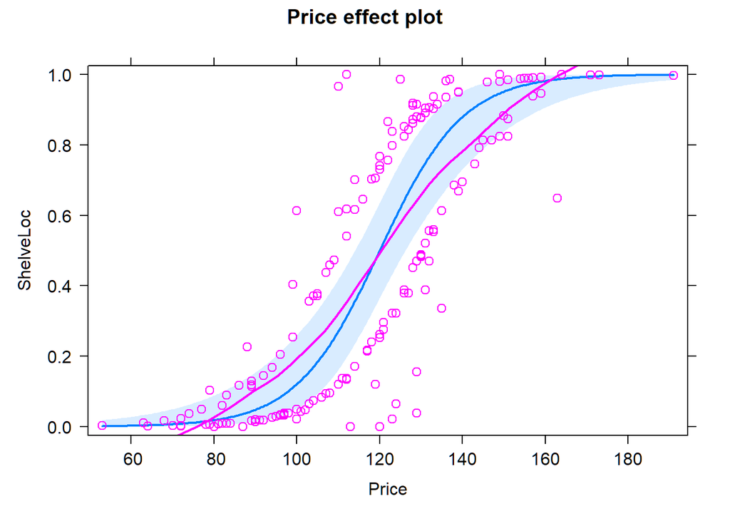

```r
plot(effect("Price", mod = model, partial.residuals=TRUE), type="response")
```

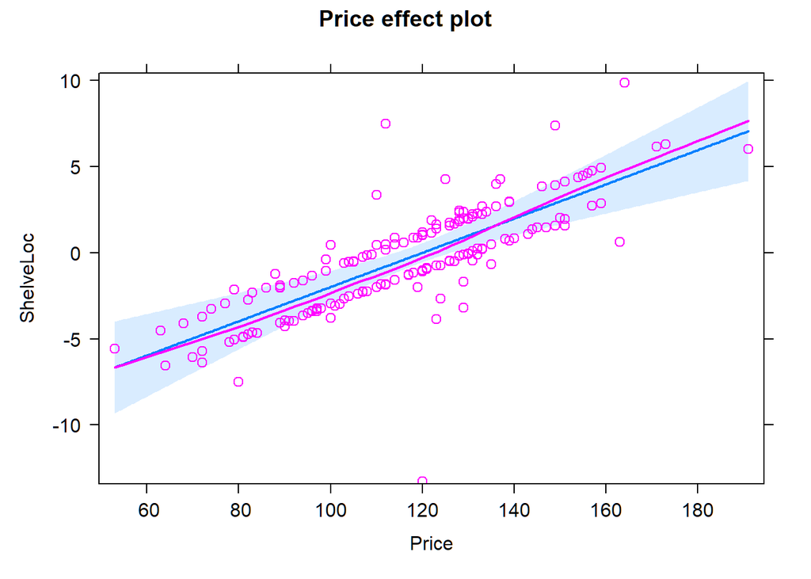

```r
plot(effect("Price", mod = model, partial.residuals=TRUE), type="link")
```

It seems like there is no non-linear problems for *Price* in logic scales.

#### 2.1.1 Refit *Price* with Polynomial

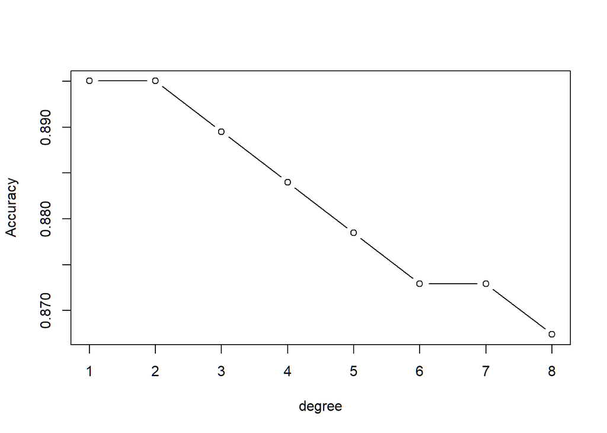

```r
set.seed(1234)
train_control <- trainControl(method="LOOCV")

fit.1 <- train(ShelveLoc ~ Sales + Price,
               method = "glm",
               data = ClassificationData,
               trControl = train_control,
               family = "binomial")
fit.2 <- train(ShelveLoc ~ Sales + poly(Price,2),
               method = "glm",
               data = ClassificationData,
               trControl = train_control,
               family = "binomial")
fit.3 <- train(ShelveLoc ~ Sales + poly(Price,3),
               method = "glm",
               data = ClassificationData,
               trControl = train_control,
               family = "binomial")
fit.4 <- train(ShelveLoc ~ Sales + poly(Price,4),
               method = "glm",
               data = ClassificationData,
               trControl = train_control,
               family = "binomial")
fit.5 <- train(ShelveLoc ~ Sales + poly(Price,5),
               method = "glm",
               data = ClassificationData,
               trControl = train_control,
               family = "binomial")
fit.6 <- train(ShelveLoc ~ Sales + poly(Price,6),
               method = "glm",
               data = ClassificationData,
               trControl = train_control,
               family = "binomial")
fit.7 <- train(ShelveLoc ~ Sales + poly(Price,7),
               method = "glm",
               data = ClassificationData,
               trControl = train_control,
               family = "binomial")
fit.8 <- train(ShelveLoc ~ Sales + poly(Price,8),
               method = "glm",
               data = ClassificationData,
               trControl = train_control,
               family = "binomial")

Accuracy <- rep(0,8)
Accuracy[1] <- fit.1$results$Accuracy
Accuracy[2] <- fit.2$results$Accuracy
Accuracy[3] <- fit.3$results$Accuracy
Accuracy[4] <- fit.4$results$Accuracy
Accuracy[5] <- fit.5$results$Accuracy
Accuracy[6] <- fit.6$results$Accuracy
Accuracy[7] <- fit.7$results$Accuracy
Accuracy[8] <- fit.8$results$Accuracy

plot(1:8, Accuracy, type = "b", xlab = "degree")
```

```r
which.max(Accuracy)
```

```
## [1] 1
```

```r
Accuracy[which.max(Accuracy)]
```

```
## [1] 0.8950276
```

We choose linear model for *Price* (Accuracy = 0.895).

#### 2.1.2 Refit *Price* with Basis Spline

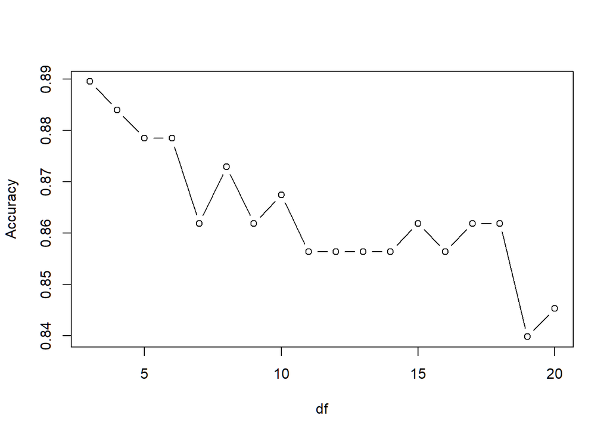

```r
Accuracy<- rep(0,18)

for (i in 3:20){
  Data <- ClassificationData
  ClassificationData$Pricebs <- bs(ClassificationData$Price, df = i)
  fit <- train(ShelveLoc ~ Sales + Pricebs,
               method = "glm",
               data = ClassificationData,
               trControl = train_control,
               family = "binomial")
  Accuracy[i-2] <- fit$results$Accuracy
}
plot(3:20, Accuracy, type='b', xlab = 'df')
```

```r
dfn <- which.max(Accuracy) + 2
dfn
```

```
## [1] 3
```

```r
Accuracy[which.max(Accuracy)]
```

```
## [1] 0.8895028
```

We choose basis spline with df = 3 for *Price* (Accuracy = 0.890).

#### 2.1.3 Refit *Price* with Nature Spline

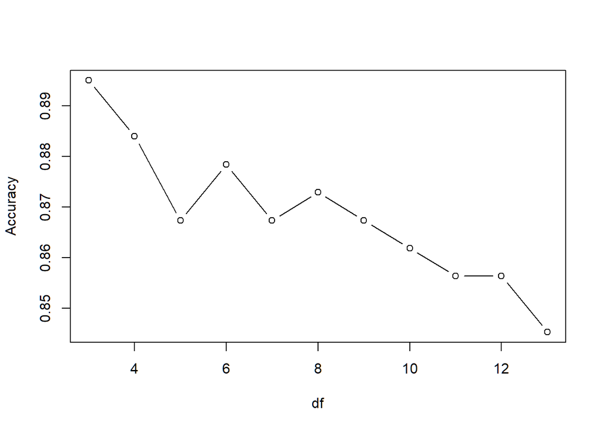

```r
Accuracy <- rep(0,10)
for (i in 3:13){
  Data <- ClassificationData
  ClassificationData$Pricens <- ns(ClassificationData$Price, df = i)
  fit <- train(ShelveLoc ~ Sales + Pricens,
               method = "glm",
               data = ClassificationData,
               trControl = train_control,
               family = "binomial")
  Accuracy[i-2] <- fit$results$Accuracy
}
plot(3:13, Accuracy, type='b', xlab = 'df')
```

```r
dfn <- which.max(Accuracy) + 2
dfn
```

```
## [1] 3
```

```r
Accuracy[which.max(Accuracy)]
```

```
## [1] 0.8950276
```

Here we choose natural spline with df = 3 (Accuracy = 0.895).

Let’s compare linear fit and natural spline fit.

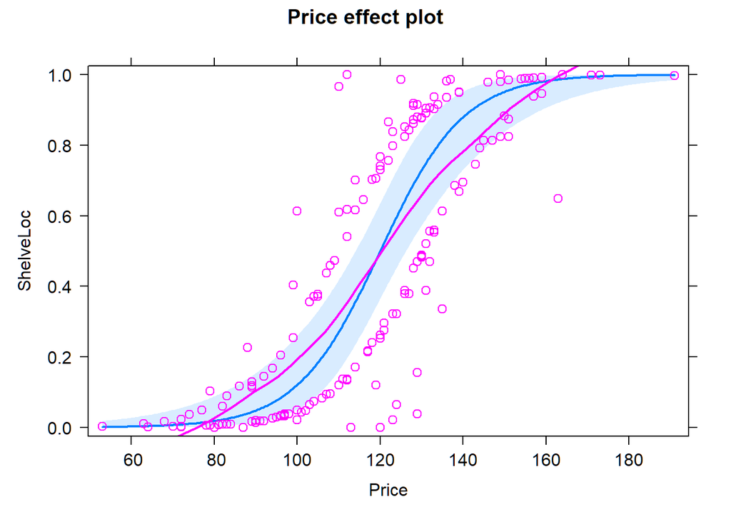

```r
model.lm.1 <-glm(ShelveLoc ~ Sales + Price,
               data = ClassificationData,
               family = "binomial")

model.ns.3 <- glm(ShelveLoc ~ Sales + ns(Price,3),
               data = ClassificationData,
               family = "binomial")
plot(effect("Price", model.lm.1, partial.residuals=TRUE), type="response")
```

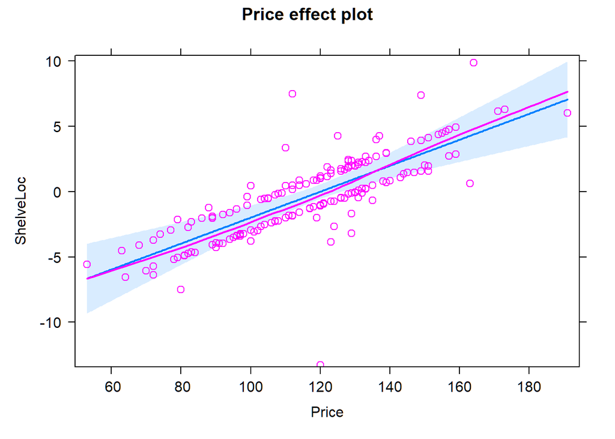

```r
plot(effect("Price", model.lm.1, partial.residuals=TRUE), type="link")
```

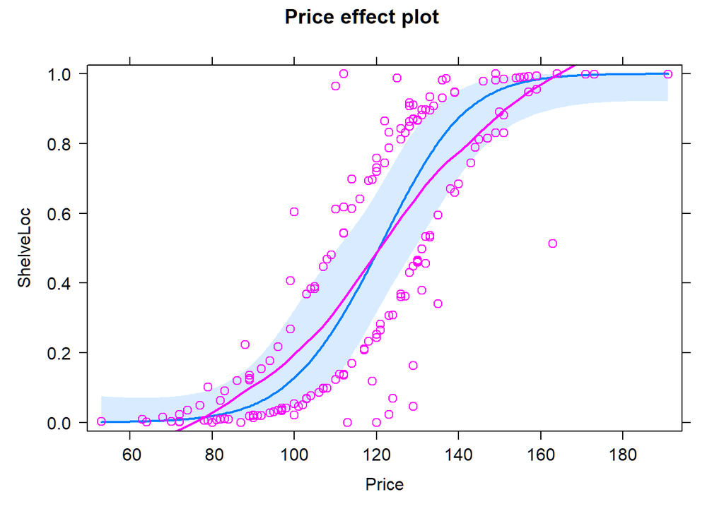

```r
plot(effect("Price", model.ns.3, partial.residuals=TRUE), type="response")
```

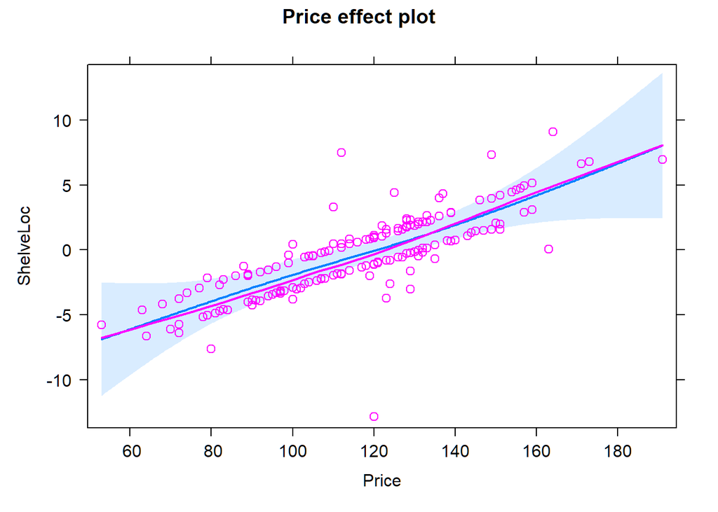

```r
plot(effect("Price", model.ns.3, partial.residuals=TRUE), type="link")
```

No obvious different, so here, I decided to choose linear fitting for *Price*.

Now that *Price* variable has been determined and I think there is no nonlinear problem for *Sales* variable, thus, the final classification predicted model has been decided.

### Best subset selection

#### Model list

```r
## 0 puts
mod.0 <- glm(ShelveLoc ~ 1,
               data = ClassificationData,
               family = "binomial")
## 1 puts
mod.1.1 <- glm(ShelveLoc ~ Sales,
               data = ClassificationData,
               family = "binomial")
mod.1.2 <- glm(ShelveLoc ~ Price,
               data = ClassificationData,
               family = "binomial")
which.max(c(deviance(mod.1.1), deviance(mod.1.2)))
```

```
## [1] 2
```

```r
## 2 puts
mod.2.1 <- glm(ShelveLoc ~ Sales + Price,
               data = ClassificationData,
               family = "binomial")
```

#### Cross-validation

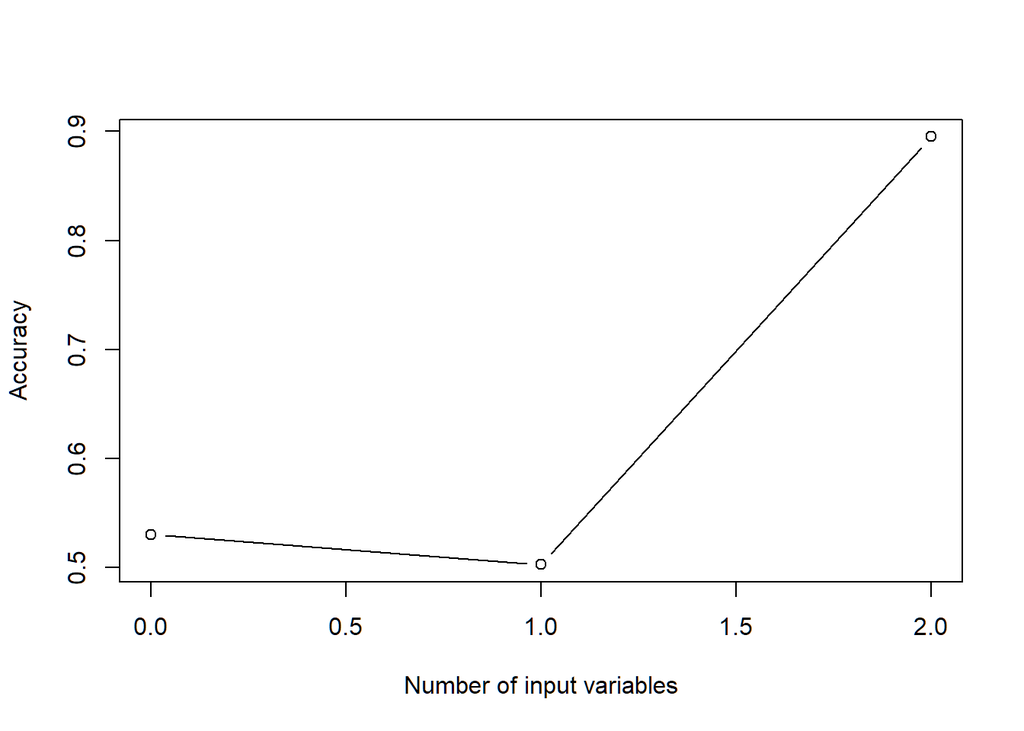

```r
ClassificationData$const <- rep(0,dim(ClassificationData)[1])
fit.0 <- train(ShelveLoc ~ const,
               data = ClassificationData,
               method = "glm",
               trControl = train_control,
               family = "binomial")
fit.1 <- train(ShelveLoc ~ Price,
               data = ClassificationData,
               method = "glm",
               trControl = train_control,
               family = "binomial")
fit.2 <- train(ShelveLoc ~ Sales + Price,
               data = ClassificationData,
               method = "glm",
               trControl = train_control,
               family = "binomial")

mod.comp <- data.frame(Accuracy = c(fit.0$results$Accuracy,
                               fit.1$results$Accuracy,
                               fit.2$results$Accuracy),
                       Inputs = c(0,1,2))
plot(mod.comp$Inputs, mod.comp$Accuracy, type = "b", xlab = "Number of input variables", ylab = "Accuracy")
```

```r
dfn_best <- mod.comp$Inputs[which.max(mod.comp$Accuracy)]
dfn_best
```

```
## [1] 2
```

This result suggested that the 2-variables model is the best.

### Test cllassification model with QDA and KNN

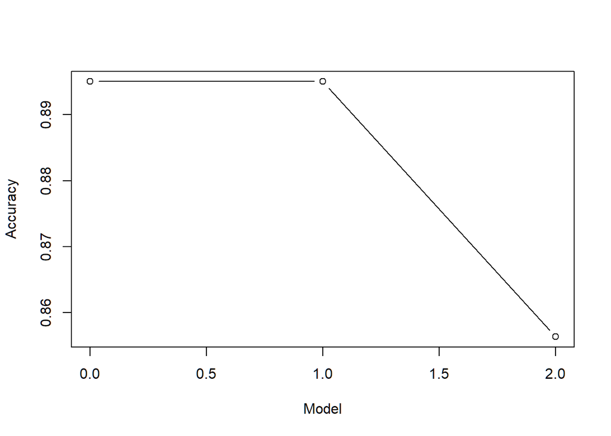

```r
  fit.QDA <- train(ShelveLoc ~ Sales + Price,
                 data = ClassificationData,
                 method = "qda",
                 trControl = train_control)
  fit.KNN <- train(ShelveLoc ~ Sales + Price,
                 data = ClassificationData,
                 method = "knn",
                 trControl = train_control,
                 preProcess = c("center","scale"))

  mod.comp <- data.frame(Accuracy = c(fit.2$results$Accuracy,
                                 fit.QDA$results$Accuracy,
                                 fit.KNN$results$Accuracy[1]),
                         Inputs = c(0,1,2))

  plot(mod.comp$Inputs, mod.comp$Accuracy, type = "b", xlab = "Model", ylab = "Accuracy")
```

```r
dfn_best <- mod.comp$Inputs[which.max(mod.comp$Accuracy)]
dfn_best
```

```
## [1] 0
```

These results suggested 2-variable model fitted by GLM is still the best.

### Interpretation for Classification model

```r
model = mod.2.1
summary(model)
```

```
##
## Call:
## glm(formula = ShelveLoc ~ Sales + Price, family = "binomial",
##     data = ClassificationData)
##
## Deviance Residuals:
##      Min        1Q    Median        3Q       Max
## -2.35839  -0.20948  -0.02382   0.25590   2.05785
##
## Coefficients:
##              Estimate Std. Error z value Pr(>|z|)
## (Intercept) -22.83091    3.97778  -5.740 9.49e-09 ***
## Sales         1.41315    0.22515   6.276 3.46e-10 ***
## Price         0.09928    0.02014   4.930 8.22e-07 ***
## ---
## Signif. codes:  0 '***' 0.001 '**' 0.01 '*' 0.05 '.' 0.1 ' ' 1
##
## (Dispersion parameter for binomial family taken to be 1)
##
##     Null deviance: 250.250  on 180  degrees of freedom
## Residual deviance:  83.767  on 178  degrees of freedom
## AIC: 89.767
##
## Number of Fisher Scoring iterations: 7
```

According to the estimated parameter in the table above, we could know each one-unit change in *Sales* will increase the log odds of choosing “good location” by 1.413, and each one-unit change in *Price* will increase the log odds of choosing “good location” by 0.099. Both p-value < 0.05 indicates that it is somewhat significant in determining the location.